# resolucion examen practico - zamora

zamora tello

6/8/2021

# EXAMEN PARCIAL

*ALUMNO:ALEXANDER RENATO ZAMORA TELLO*

*CODIGO :17160048*

## Parte 1 - Usar R nativo (no librer´ıas)

**ejercicio 1**

```r
variable1 <- function(h, x = 81.4){
  if (h == 1000){
    var1 = 81.4
  } else if (h<=3000 & h> 1000){
    var1 = x - 2*((h-1000)%/%500)
  } else if (h > 3000 & h<=4000){
    var1 = x - 8 - 0.5*((h-3000)%/%500)
  } else if (h > 4000){
    var1 = x - 9
  } else {
    print("no hay respuesta!")
  }
  return(var1)
}

variable1(1000)
```

```
## [1] 81.4
```

**ejercicio 2**

```r
A <- rbind(c(2, 1, 3),
           c(5, -4, 1),
           c(1, -1, -4))
B <- c(7, -19, 4)
solve(A, B)
```

```
## [1]  2.923077  7.846154 -2.230769
```

## Parte 2

**2A**

```r
data1 <- as_tibble(read.csv("mods_clima_uh.csv"))
(data2 <- data1 %>%
  dplyr::filter(uh_name =="Cuenca Ushusuma", bh_esc == "Observado" )%>%
  group_by(uh_name) %>%
  summarise(bh_pc = sum(bh_pc, na.rm = T)))
```

```
## # A tibble: 1 x 2
##   uh_name         bh_pc
##   <chr>           <dbl>
## 1 Cuenca Ushusuma  286.
```

**2B**

```r
(data3 <- data1 %>%
  dplyr::select(uh_name,bh_month,bh_pc,bh_esc)%>%
  dplyr::filter(uh_name == "Cuenca Ushusuma") %>%
  pivot_wider(names_from = "bh_esc", values_from = "bh_pc"))
```

```
## # A tibble: 12 x 6
##    uh_name         bh_month Observado `ACCESS 1.0` `HadGEM2-ES` `MPI-ESM-LR`
##    <chr>              <int>     <dbl>        <dbl>        <dbl>        <dbl>
##  1 Cuenca Ushusuma        1    85.1         93.7         76.6         68.1
##  2 Cuenca Ushusuma        2    85.2         68.1         76.6         76.6
##  3 Cuenca Ushusuma        3    53.9         35.9         48.5         55.6
##  4 Cuenca Ushusuma        4    11.0         11.0         10.3         10.7
##  5 Cuenca Ushusuma        5     0.994        0.392        0.392        0.686
##  6 Cuenca Ushusuma        6     1.45         0.967        0.967        1.65
##  7 Cuenca Ushusuma        7     1.48         0.983        0.983        2.42
##  8 Cuenca Ushusuma        8     1.69         1.69         1.69         2.25
##  9 Cuenca Ushusuma        9     0.894        0.736        0.736        1.16
## 10 Cuenca Ushusuma       10     3.31         3.1          3.64         5.77
## 11 Cuenca Ushusuma       11     6.28         3.98         6.28         6.93
## 12 Cuenca Ushusuma       12    34.7         22.0         28.9         32.4
```

```r
(OB_ACCES <-pbias(data3$`ACCESS 1.0`, data3$Observado, na.rm = T))
```

```
## [1] -15.2
```

```r
(OB_HadGE <-pbias(data3$`HadGEM2-ES` , data3$Observado , na.rm = T))
```

```
## [1] -10.6
```

```r
(OB_MPIEM <-pbias(data3$`MPI-ESM-LR` , data3$Observado , na.rm = T))
```

```
## [1] -7.6
```

**2C**

**el escenario mas preciso es el de “MPI-ESM-LR” ya que tiene un valor de -7.6 de sesgo si es sesgo es mas cercano a 0 es mas preciso**

**2D**

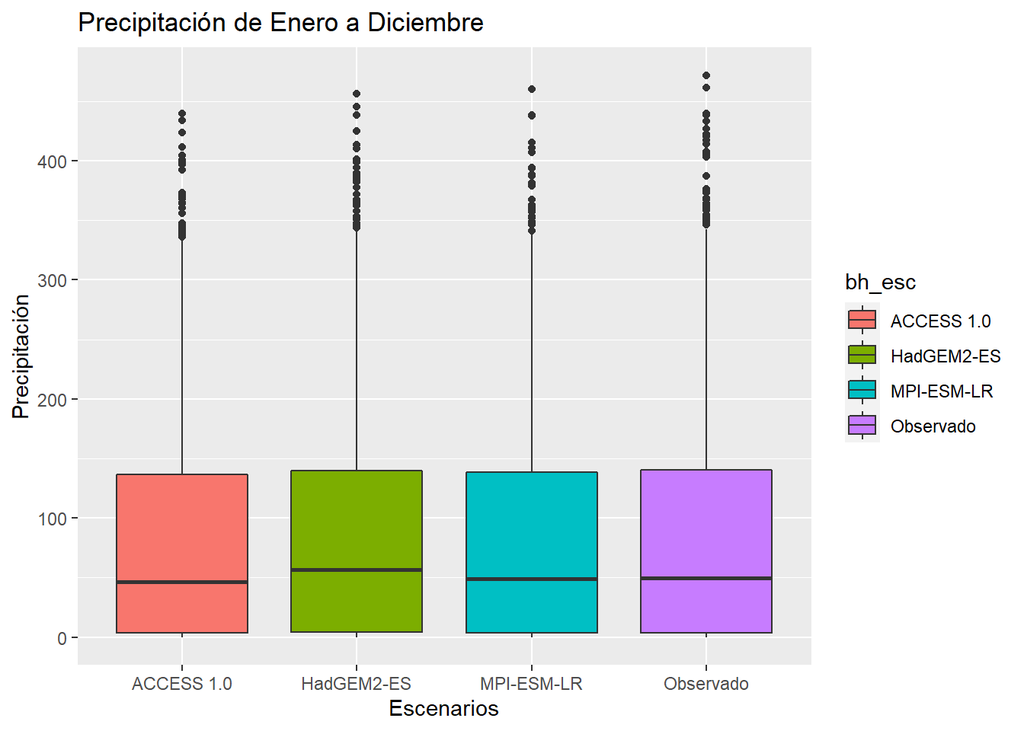

```r
(data4 <- data1 %>%
  group_by(bh_month, bh_esc) %>%
  ggplot(mapping = aes(x = bh_esc, y = bh_pc, fill = bh_esc))+
  geom_boxplot()+
  labs (title = "Precipitación de Enero a Diciembre",
       x = "Escenarios",
       y = "Precipitación"
  ))
```

## Parte 3

**Pregunta1**

```r
df_t1 <- as_tibble(read.csv("temperatureDataset.csv"))
(df_t2 <- df_t1 %>%
  dplyr::mutate(DATE = as.Date(DATE, format = "%d/%m/%Y")) %>%
  dplyr::select(DATE, qc00000805) %>%
  rename(tt = qc00000805) %>%
  dplyr::mutate(tt = ifelse(tt == -99.9, NA, tt)))
```

```
## # A tibble: 31,775 x 2
##    DATE          tt
##    <date>     <dbl>
##  1 1928-11-02    NA
##  2 1928-11-03    NA
##  3 1928-11-04    NA
##  4 1928-11-05    NA
##  5 1928-11-06    NA
##  6 1928-11-07    NA
##  7 1928-11-08    NA
##  8 1928-11-09    NA
##  9 1928-11-10    NA
## 10 1928-11-11    NA
## # ... with 31,765 more rows
```

**1 A**

```r
(df_t3 <- df_t2 %>%
  dplyr::filter(DATE >= "1983-09-01" & DATE < "1984-08-31" |
                  DATE >= "1997-09-01" & DATE < "1998-08-31"))
```

```
## # A tibble: 729 x 2
##    DATE          tt
##    <date>     <dbl>
##  1 1983-09-01  22
##  2 1983-09-02  22
##  3 1983-09-03  22.6
##  4 1983-09-04  22
##  5 1983-09-05  24
##  6 1983-09-06  24.4
##  7 1983-09-07  24
##  8 1983-09-08  26
##  9 1983-09-09  24.4
## 10 1983-09-10  25
## # ... with 719 more rows
```

```r
sum(is.na(df_t3$tt))
```

```
## [1] 1
```

**1 B**

```r
(df_t4 <- df_t2 %>%
  group_by(DATE = str_sub(DATE, 1, 7)) %>%
  mutate(MissVal = sum(is.na(tt))*100/n()) %>%
  summarise(
    tt = mean(tt, na.rm = T),
    MissVal = unique(MissVal)
  ) %>%
  mutate(
    tt = ifelse(MissVal >= 5, NA, tt),
    DATE = as.Date(sprintf("%1$s-01", DATE)),
    month = str_sub(DATE, 6, 7)
  ))
```

```
## # A tibble: 1,044 x 4
##    DATE          tt MissVal month
##    <date>     <dbl>   <dbl> <chr>
##  1 1928-11-01    NA     100 11
##  2 1928-12-01    NA     100 12
##  3 1929-01-01    NA     100 01
##  4 1929-02-01    NA     100 02
##  5 1929-03-01    NA     100 03
##  6 1929-04-01    NA     100 04
##  7 1929-05-01    NA     100 05
##  8 1929-06-01    NA     100 06
##  9 1929-07-01    NA     100 07
## 10 1929-08-01    NA     100 08
## # ... with 1,034 more rows
```

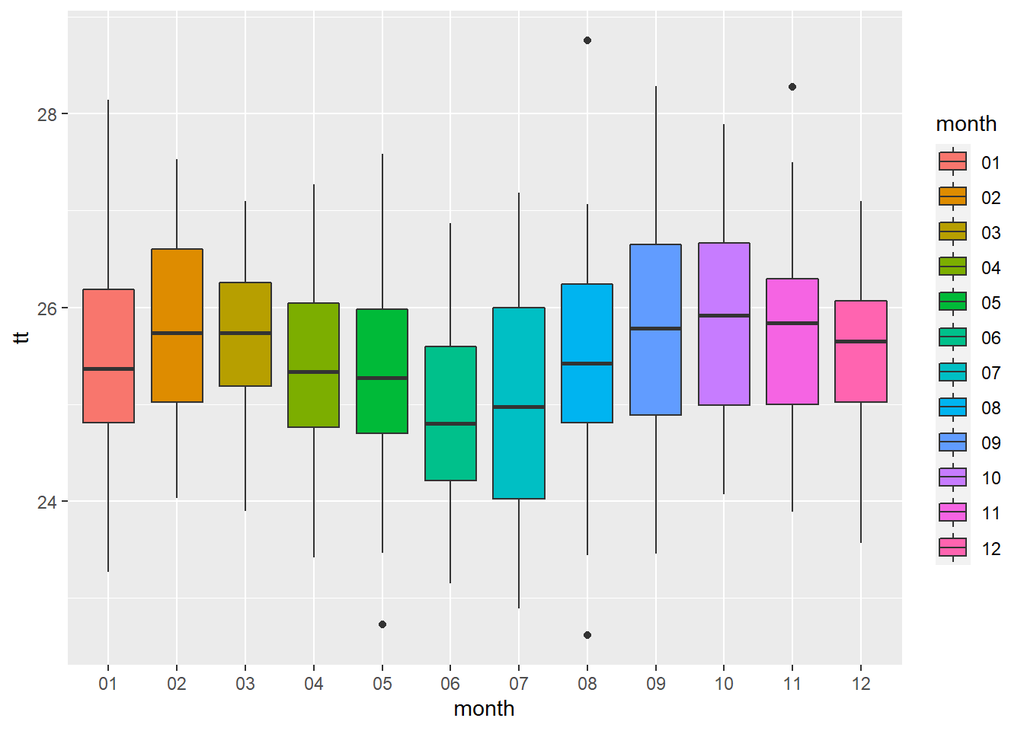

```r
ggplot(data = df_t4, mapping = aes(x = month, y = tt, fill = month))+
  geom_boxplot()
```

**1 C**

```r
(df_t5 <- df_t2 %>%
    group_by(DATE = str_sub(DATE, 1, 7)) %>%
    mutate(MissVal = sum(is.na(tt))) %>%
    summarise(
      tt = mean(tt, na.rm = T),
      MissVal = unique(MissVal)
    ) %>%
    dplyr::filter(DATE >= "2005-01-01" & DATE < "2005-12-31" |
                    DATE >= "2010-01-01" & DATE < "2010-12-31") %>%
    mutate(
      DATE = as.Date(sprintf("%1$s-01", DATE)),
      month = str_sub(DATE, 6, 7)
    ))
```

```
## # A tibble: 22 x 4
##    DATE          tt MissVal month
##    <date>     <dbl>   <int> <chr>
##  1 2005-02-01  25.0       0 02
##  2 2005-03-01  24.8       0 03
##  3 2005-04-01  24.5       0 04
##  4 2005-05-01  24.5       0 05
##  5 2005-06-01  24.8       0 06
##  6 2005-07-01  23.7       0 07
##  7 2005-08-01  25.1       0 08
##  8 2005-09-01  24.5       0 09
##  9 2005-10-01  24.4       0 10
## 10 2005-11-01  24.8       0 11
## # ... with 12 more rows
```

**1 D**

```r
funcion2 <- function(data_temp){
  dplyr::filter(data_temp, DATE >= "1980-01-01" & DATE < "1995-12-31" |
                  DATE >= "1996-01-01" & DATE < "2010-12-31") %>%
    group_by(DATE = str_sub(DATE, 1,7)) %>%
    summarise(ttmean = mean(tt, na.rm = T)) %>%
    return()
    }
(df_t6 <- funcion2(df_t2))
```

```
## # A tibble: 372 x 2
##    DATE    ttmean
##    <chr>    <dbl>
##  1 1980-01   26.8
##  2 1980-02   25.3
##  3 1980-03   27.1
##  4 1980-04   26.3
##  5 1980-05   25.9
##  6 1980-06   25.6
##  7 1980-07   25.8
##  8 1980-08   25.6
##  9 1980-09   26.1
## 10 1980-10   26.4
## # ... with 362 more rows
```

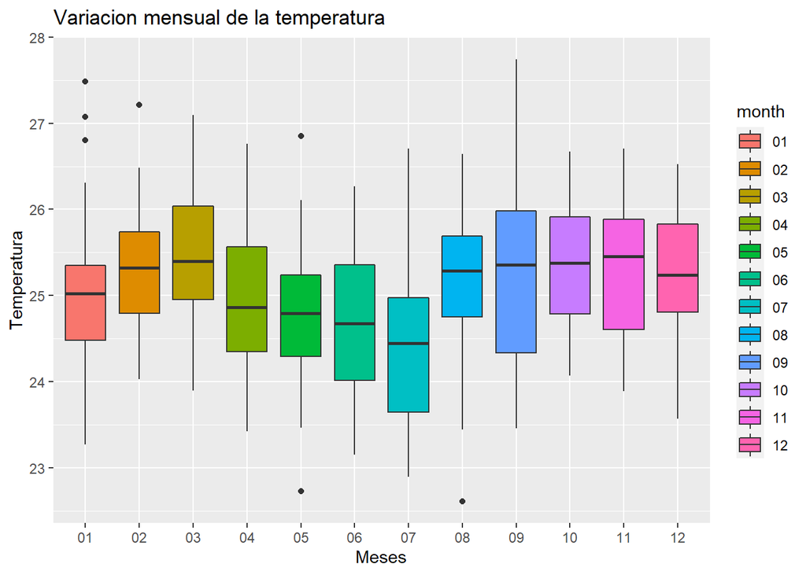

```r
df_t6 %>%
  mutate(month = str_sub(DATE, 6, 7)) %>%
  ggplot(mapping = aes(x = month, y = ttmean, fill = month))+
  geom_boxplot()+
  ggtitle("Variacion mensual de la temperatura")+
  labs(
    x = "Meses",
    y = "Temperatura"
    )
```

**podemos observar 3 valores atipicos en el mes de enero que estan entre 26 y 28 C°, en cambio en el mes de tenemos dos valores atipicos pero uno de ellos es menor de 23 C°y hay un solo valor atipico en los meses de febrero y agosto**

**1 E**

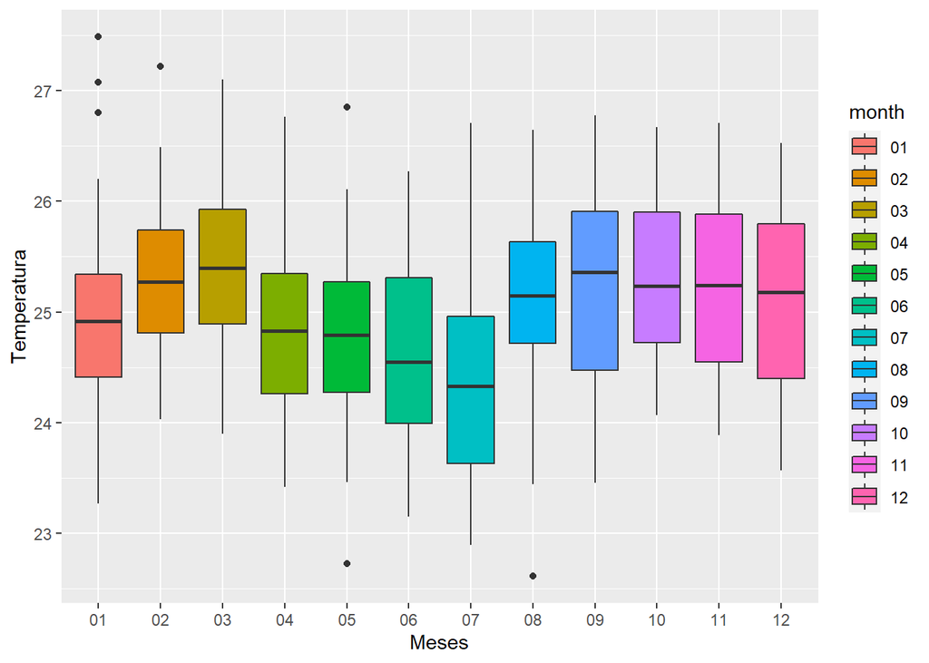

```r
df_t4 %>%
  dplyr::filter(DATE >= "1980-01-01" & DATE < "2013-12-31") %>%
  ggplot(mapping = aes(x = month, y = tt, fill = month))+
  geom_boxplot()+
  labs(
    x = "Meses",
    y = "Temperatura"
  )
```

**se puede notar en el grafico que la mediana de las cajas de los meses octubre , noviembre y diciembre son casi iguales con un valor superior a 25 C°. se puede notar un valor atipico en el mes de agosto de una temperatura menor a 23 C°. el mes que tiene mayor cantidad de valores atipicos y la max temperatura es el de enero con una tmax superior 27 C°**